# Regression Exercises

## Computing

### Loading the data

```r
data(solubility)

# This gives us the names of all objects in a  regex way, quite cool.
ls(pattern = "^solT")
```

### Ordinary Linear Regression

```r
training_data <- solTrainXtrans
training_data$solubility <- solTrainY
```

```r
corrplot(cor(training_data), method = "color", order = "hclust")
```

Most variables are not highly correlated, but there is definitely multicollinearity within the data.

```r
lm_fit_all_predictors <- lm(solubility ~ ., data = training_data)
summary(lm_fit_all_predictors)
```

```r
lm_pred_1 <- predict(lm_fit_all_predictors, solTestXtrans)
head(lm_pred_1)
```

```r
lm_values_1 <- data.frame(obs = solTestY, pred = lm_pred_1)
defaultSummary(lm_values_1)
```

Using the robust linear model. What is the robust linear model again? Huber approach?

```r
rlm_fit_all_predictors <- rlm(solubility ~ ., data = training_data)
```

```r
ctrl <- trainControl(method = "cv", number = 10)

lm_fit_1 <- train(x = solTrainXtrans, y = solTrainY,
                  method = "lm", trControl = ctrl)
```

```r
lm_fit_1
```

For models built to explain, we need to look at residuals.

For models built to predict, residuals give us an idea about areas where the model doesn’t perform well.

```r
plot(lm_fit_1$finalModel$residuals, lm_fit_1$pred)
```

```r
xyplot(solTrainY ~ predict(lm_fit_1),
 type = c("p", "g"),
 xlab = "Predicted", ylab = "Observed")
```

The plot shows real vs predicted values. They are meant to fall along the diagonal line and randomly distributed along the line.

```r
xyplot(resid(lm_fit_1) ~ predict(lm_fit_1),
        type = c("p", "g"),
        xlab = "Predicted", ylab = "Residuals")
```

The residuals are meant to be randomly scattered along the horizontal axis. It’s the same as the previous plot except flipped.

```r
cor_thres <- 0.9
too_high <- findCorrelation(cor(solTrainXtrans), cor_thres)

too_high
```

```r
corrpred <- names(solTrainXtrans[too_high])
corrpred
```

These are the columns that are recommended to be removed based on the correlation threshold.

```r
train_x_filtered <- solTrainXtrans[, -too_high]

lm_filtered <- train(train_x_filtered, solTrainY, method = "lm",
                     trControl = ctrl)

lm_filtered
```

This is a mistake in the book. The predictors were not filtered. There doesn’t seem to be any difference in predictive accuracy though.

**Robust Linear Regression**

RLM doesn’t allow the covariance matrix to be singular. What is this guy talking about?

```r
# Build the RLM

rlm_pca <- train(train_x_filtered, solTrainY,
                 method = "rlm",
                 preProcess = "pca",
                 trControl = ctrl)

rlm_pca
```

### Partial Least Squares

```r
library(pls)

pls_fit <- plsr(solubility ~ ., data = training_data)

predict(pls_fit, solTestXtrans[1:5,], ncomp = 1:2)
```

```r
pls_tune <- train(solTrainXtrans, solTrainY,
                  method = "pls",
                  tuneLength = 20,
                  trControl = ctrl,
                  preProcess = c("center", "scale"))

plot(pls_tune)
pls_tune
```

```r
ranf_model <- train(solTrainXtrans, solTrainY,
                  method = "rf",
                  tuneLength = 10,
                  trControl = ctrl)
```

### Penalised regression models

Ridge regression

## Exercises

### 6.1 IR spectroscopy

```r
data(tecator)
```

```r
corrplot(cor(absorp), method = "color")
```

Jesus Christ, what is this? lol

Everything is positively correlated with everything.

1. Use PCA to determine the effective dimension of the data

```r
data <- as.data.frame(absorp)

trans <- preProcess(x = data,
                    method = c("BoxCox", "center", "scale", "pca"))

trans
```

```
Created from 215 samples and 100 variables

Pre-processing:
  - Box-Cox transformation (100)
  - centered (100)
  - ignored (0)
  - principal component signal extraction (100)
  - scaled (100)

Lambda estimates for Box-Cox transformation:
   Min. 1st Qu.  Median    Mean 3rd Qu.    Max.
 -1.700  -1.600  -1.300  -1.303  -1.075  -0.900

PCA needed 2 components to capture 95 percent of the variance
```

Yep, as the correlation plot suggested, it only needs 2 variables to capture 95% of the variance within the data. The dataset is very redundant.

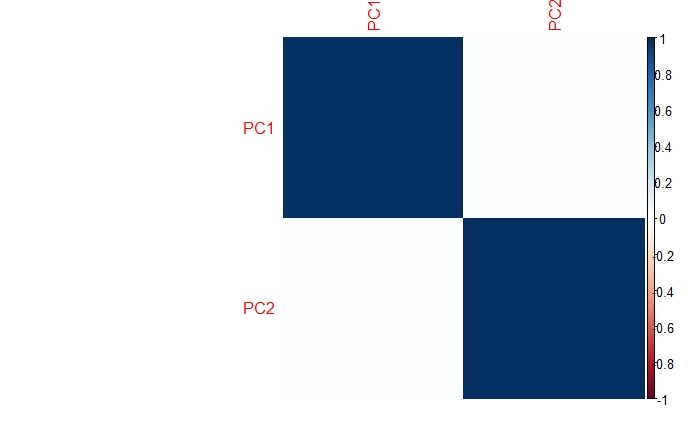

```r
processed_data <- predict(trans, data)

corrplot(cor(processed_data), method = "color")
```

They are completely uncorrelated.

### Models

**OLS Regression**

```r
ols_model_1
```

```
Linear Regression

215 samples
100 predictors

No pre-processing
Resampling: Cross-Validated (10 fold)
Summary of sample sizes: 194, 193, 193, 195, 192, 194, ...
Resampling results:

  RMSE      Rsquared   MAE
  1.800322  0.9703039  1.255717

Tuning parameter 'intercept' was held constant at a value of TRUE
```

97% of the variation was explained. I wouldn’t trust it. I don’t know if it’s adjusted R^2 or not.

```r
ols_model_2
```

```
Linear Regression

215 samples
100 predictors

No pre-processing
Resampling: Cross-Validated (10 fold)
Summary of sample sizes: 195, 195, 193, 192, 193, 194, ...
Resampling results:

  RMSE      Rsquared   MAE
  2.526297  0.9613616  1.749186

Tuning parameter 'intercept' was held constant at a value of TRUE
```

```r
ols_model_3
```

```
Linear Regression

215 samples
100 predictors

No pre-processing
Resampling: Cross-Validated (10 fold)
Summary of sample sizes: 194, 193, 195, 193, 194, 193, ...
Resampling results:

  RMSE     Rsquared   MAE
  1.13352  0.8678753  0.7268765

Tuning parameter 'intercept' was held constant at a value of TRUE
```

Ok, next I will only use the first column. There are too many variables.

**OLS with centering, scaling and PCA**

```r
ols_model_processed
```

```
Linear Regression

215 samples
100 predictors

Pre-processing: Box-Cox transformation (100), centered (100), scaled (100), principal component signal extraction (100)
Resampling: Cross-Validated (10 fold)
Summary of sample sizes: 195, 193, 192, 194, 194, 193, ...
Resampling results:

  RMSE      Rsquared   MAE
  8.151269  0.3454529  6.702289

Tuning parameter 'intercept' was held constant at a value of TRUE
```

What is going on with this? The predictions are so much worse. So much for preprocessing.

**PLS**

```r
pls_model
```

```
Partial Least Squares

215 samples
100 predictors

Pre-processing: Box-Cox transformation (100), centered (100), scaled (100)
Resampling: Cross-Validated (10 fold)
Summary of sample sizes: 193, 192, 195, 194, 195, 192, ...
Resampling results across tuning parameters:

  ncomp  RMSE      Rsquared   MAE
   1     8.535742  0.2742524  7.1167096
   2     6.341788  0.6079571  5.2784850
   3     3.956497  0.8411325  3.0509403
   4     3.456741  0.8867154  2.7339728
```

[output cut: 39 more lines]

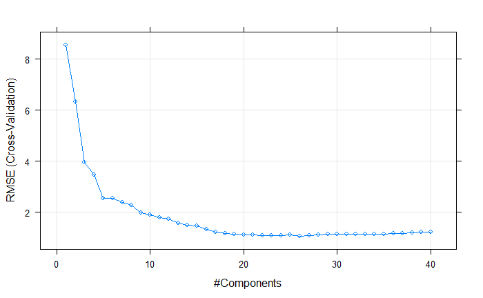

This is the best one yet, PLS with preprocessing.

**Ridge regression**

```r
ridge_model
```

```
Ridge Regression

215 samples
100 predictors

Pre-processing: Box-Cox transformation (100), centered (100), scaled (100)
Resampling: Cross-Validated (10 fold)
Summary of sample sizes: 194, 194, 194, 194, 194, 192, ...
Resampling results across tuning parameters:

  lambda       RMSE      Rsquared   MAE
  0.000000000  1.328319  0.9837912  0.9890815
  0.007142857  2.771035  0.9325763  2.1525788
  0.014285714  2.986769  0.9189778  2.3163931
  0.021428571  3.140381  0.9093754  2.4199788
  0.028571429  3.261657  0.9018714  2.4994986
  0.035714286  3.365085  0.8954957  2.5665048
  0.042857143  3.457660  0.8897574  2.6275781
  0.050000000  3.542973  0.8843938  2.6882564
  0.057142857  3.622990  0.8792576  2.7455488
  0.064285714  3.698854  0.8742628  2.8011336
  0.071428571  3.771272  0.8693583  2.8558988
  0.078571429  3.840711  0.8645133  2.9113691
  0.085714286  3.907498  0.8597091  2.9656955
  0.092857143  3.971876  0.8549350  3.0189941
  0.100000000  4.034037  0.8501848  3.0708264

RMSE was used to select the optimal model using the smallest value.
The final value used for the model was lambda = 0.
```

It worked with a reasonable MAE value. Not as good as PLS but not as bad as ordinary regression and PCR.

Though, what does Lambda 0 mean? It means there is no penalty term for coefficients. Therefore, this is ordinary regression. Great.

**Lasso regression**

```r
lasso_model
```

```
The lasso

215 samples
100 predictors

Pre-processing: Box-Cox transformation (100), centered (100), scaled (100)
Resampling: Cross-Validated (10 fold)
Summary of sample sizes: 194, 194, 193, 192, 192, 192, ...
Resampling results across tuning parameters:

  fraction     RMSE      Rsquared   MAE
  0.000000000  9.810773        NaN  8.3338619
  0.007142857  1.657290  0.9746315  1.1993800
  0.014285714  1.455538  0.9799817  1.0734253
  0.021428571  1.327584  0.9835365  0.9859321
  0.028571429  1.211304  0.9862481  0.9103243
  0.035714286  1.154134  0.9874305  0.8749950
  0.042857143  1.126128  0.9879304  0.8579521
  0.050000000  1.093561  0.9885379  0.8323851
  0.057142857  1.074791  0.9888747  0.8127258
  0.064285714  1.068215  0.9890044  0.8068320
  0.071428571  1.060146  0.9891975  0.7997810
  0.078571429  1.054620  0.9892901  0.7944667
  0.085714286  1.052118  0.9892738  0.7926256
  0.092857143  1.053476  0.9892020  0.7944258
  0.100000000  1.054050  0.9891362  0.7962568

RMSE was used to select the optimal model using the smallest value.
The final value used for the model was fraction = 0.08571429.
```

Yes! I beat PLS with lasso.

**Elastic net**

This is the final model. It’s time for the elastic net.

```r
enet_grid <- data.frame(.fraction = seq(0, 0.1, length = 15))

enet_model <- train(data, endpoints[,1],
                     method = "enet",
                     tuneLength = 30,
                     trControl = trainControl(method = "cv", number = 10),
                     preProcess = c("BoxCox", "center", "scale"))

enet_model
```

**Model comparison**

```r
summary(models)
```

```
Call:
summary.resamples(object = models)

Models: OLS, PCR, PLS, ridge, lasso, elastic_net
Number of resamples: 10

MAE
                 Min.   1st Qu.    Median      Mean   3rd Qu.      Max. NA's
OLS         1.0034036 1.1203997 1.2336483 1.2557173 1.3386136 1.6429303    0
PCR         5.6087042 5.9868688 6.8997310 6.7022894 7.1229439 7.7534513    0
PLS         0.5576718 0.7860126 0.8689652 0.8165762 0.8844339 0.9429749    0
ridge       0.6991265 0.8697660 0.9876320 0.9890815 1.1039172 1.2322110    0
lasso       0.6323790 0.6549836 0.7724259 0.7926256 0.8505003 1.2140681    0
elastic_net 0.6103804 0.7157745 0.7746596 0.7972196 0.8248262 1.1358355    0

RMSE
                 Min.   1st Qu.    Median     Mean  3rd Qu.     Max. NA's
OLS         1.2582123 1.4710857 1.7164924 1.800322 2.099844 2.503070    0
PCR         6.8107321 6.9239803 8.5522009 8.151269 8.809266 9.843728    0
PLS         0.6993031 1.0279684 1.1284316 1.078123 1.201766 1.263599    0
ridge       0.8585236 1.1489121 1.3949257 1.328319 1.510334 1.672698    0
lasso       0.8448575 0.8933796 0.9636328 1.052118 1.094460 1.713822    0
elastic_net 0.8718575 0.9690817 1.0513438 1.081957 1.138459 1.546892    0

Rsquared
                 Min.   1st Qu.    Median      Mean   3rd Qu.      Max. NA's
OLS         0.9564914 0.9611797 0.9686700 0.9703039 0.9809061 0.9823171    0
PCR         0.1630762 0.2101969 0.3327400 0.3454529 0.4499585 0.5806041    0
PLS         0.9817759 0.9858310 0.9897481 0.9884467 0.9911931 0.9949235    0
ridge       0.9728481 0.9777170 0.9855817 0.9837912 0.9902210 0.9913330    0
lasso       0.9778835 0.9872703 0.9914860 0.9892738 0.9919015 0.9947100    0
elastic_net 0.9804791 0.9847677 0.9899247 0.9881935 0.9916160 0.9927297    0
```

```r
summary(model_differences)
```

```
Call:
summary.diff.resamples(object = model_differences)

p-value adjustment: bonferroni
Upper diagonal: estimates of the difference
Lower diagonal: p-value for H0: difference = 0

MAE
            OLS       PCR       PLS       ridge     lasso     elastic_net
OLS                   -5.446572  0.439141  0.266636  0.463092  0.458498
PCR         3.373e-08            5.885713  5.713208  5.909664  5.905070
PLS         0.0010227 1.890e-08           -0.172505  0.023951  0.019357
ridge       0.1702255 4.051e-08 0.1278693            0.196456  0.191862
lasso       0.0008315 2.209e-08 1.0000000 0.2941067           -0.004594
elastic_net 0.0068779 3.612e-08 1.0000000 0.8380305 1.0000000

RMSE
            OLS       PCR       PLS       ridge     lasso     elastic_net
OLS                   -6.350947  0.722199  0.472003  0.748205  0.718365
PCR         2.645e-07            7.073146  6.822950  7.099152  7.069312
PLS         0.009498  1.202e-07           -0.250196  0.026005 -0.003834
ridge       0.358459  2.935e-07 0.210847             0.276201  0.246362
lasso       0.001125  2.082e-07 1.000000  0.613589            -0.029839
elastic_net 0.020051  2.765e-07 1.000000  1.000000  1.000000

Rsquared
            OLS       PCR        PLS        ridge      lasso      elastic_net
OLS                    0.6248510 -0.0181429 -0.0134874 -0.0189700 -0.0178896
PCR         8.363e-06            -0.6429939 -0.6383384 -0.6438210 -0.6427406
PLS         0.002203  5.274e-06              0.0046555 -0.0008271  0.0002533
ridge       0.298414  5.736e-06  1.000000              -0.0054826 -0.0044022
lasso       0.002012  5.626e-06  1.000000   1.000000               0.0010804
elastic_net 0.019213  5.513e-06  1.000000   1.000000   1.000000
```

These results suggest that it’s actually quite accurate at predicting the performance. There is no significant difference between the performance of lasso, ridge and elastic net models. I think this is good enough.

The models are absolutely great at determining the content of water as a beginning. I’m done with these exercises.

Thoughts: People use the Free lunch theorem as if there wasn’t an inherent difference in models. It’s a safe bet I think to use a random forest model instead of any type of linear regression model.